# Healthcare Analytics: Breast Cancer Classification Using Machine Learning Models

Kelly Adu - Gyamfi

2025-10-15

# 1 Data Description

**Original reference:**  
Wolberg, W. H., & Mangasarian, O. L. (1990). *Multisurface method of pattern separation for medical diagnosis applied to breast cytology.* *Proceedings of the National Academy of Sciences*, 87(23), 9193–9196.  
https://archive.ics.uci.edu/ml/datasets/Breast+Cancer+Wisconsin+(Original)

**Data Generation/Collection:**  
The data were collected from the University of Wisconsin Hospitals, Madison, by Dr. William H. Wolberg. Cytological measurements were taken directly from digitized images of fine needle aspirate samples. Each feature is an integer value ranging from 1 to 10, representing the degree of cell abnormality. The dataset is widely used for supervised learning and binary classification benchmarking.

**Size:**

```r
# Variable description table
variable_desc <- data.frame(
  Variable = c("Cl.thickness", "Cell.size", "Cell.shape", "Marg.adhesion",
               "Epith.c.size", "Bare.nuclei", "Bl.cromatin", "Normal.nucleoli",
               "Mitoses", "Class"),
  Type = rep("Numerical", 9) %>% c("Categorical"),
  Description = c("Clump thickness (1-10)",
                  "Uniformity of cell size (1-10)",
                  "Uniformity of cell shape (1-10)",
                  "Marginal adhesion (1-10)",
                  "Single epithelial cell size (1-10)",
                  "Bare nuclei count (1-10)",
                  "Bland chromatin (1-10)",
                  "Normal nucleoli (1-10)",
                  "Mitoses count (1-10)",
                  "Diagnosis: benign or malignant")
)

kable(variable_desc, caption = "Table 1: Variable Descriptions") %>%
  kable_styling(bootstrap_options = c("striped", "hover"))
```

Table 1: Variable Descriptions

| Variable | Type | Description |
| --- | --- | --- |
| Cl.thickness | Numerical | Clump thickness (1-10) |
| Cell.size | Numerical | Uniformity of cell size (1-10) |
| Cell.shape | Numerical | Uniformity of cell shape (1-10) |
| Marg.adhesion | Numerical | Marginal adhesion (1-10) |
| Epith.c.size | Numerical | Single epithelial cell size (1-10) |
| Bare.nuclei | Numerical | Bare nuclei count (1-10) |
| Bl.cromatin | Numerical | Bland chromatin (1-10) |
| Normal.nucleoli | Numerical | Normal nucleoli (1-10) |
| Mitoses | Numerical | Mitoses count (1-10) |
| Class | Categorical | Diagnosis: benign or malignant |

# 2 Formulating Practical and Analytical Questions

Developing predictive models for breast cancer diagnosis requires translating real-world clinical needs into structured analytical questions.  
The dataset contains cytological features derived from fine needle aspirate (FNA) samples, each labeled as *benign* or *malignant*.  
The goal is to use these measurable features to support early cancer detection through accurate and interpretable classification models.

## 2.1 **Practical Questions**

1. Can cytological characteristics of breast cell nuclei reliably predict whether a tumor is **benign or malignant**?
2. Which **features** contribute most to distinguishing malignant from benign tumors?
3. Which **modeling approach** (logistic regression, neural network, decision tree, or ensemble) yields the **most accurate and interpretable** results?
4. How can model predictions be **optimized** to minimize misclassification, especially false negatives (malignant cases predicted as benign)?
5. Can predictive analytics assist healthcare professionals in making **early and cost-effective** diagnostic decisions?

## 2.2 **Analytical Questions**

1. Can a **binary classification model** accurately predict tumor type (*benign* vs. *malignant*) based on cytological features?
2. Which predictor variables show the **strongest statistical or computational influence** on malignancy?
3. How do **performance metrics** (ROC-AUC, accuracy, sensitivity, specificity, and F1-score) differ among the candidate models?
4. Can **neural network architectures** (e.g., perceptrons with different activation functions) outperform classical models like logistic regression?
5. Can **decision trees** and **bagging ensembles** improve performance by addressing nonlinearity and reducing model variance?
6. Which **optimal threshold** maximizes diagnostic effectiveness while minimizing clinical misclassification costs?

# 3 Methodology

## 3.1 Research Design and Analytical Framework

This study employs a comparative predictive modeling approach to develop and evaluate multiple machine learning algorithms for breast cancer classification. The methodology follows a systematic pipeline encompassing data preprocessing, exploratory analysis, model development, evaluation, and interpretation.

```r
methodology_steps <- data.frame(
  Step = c("1. Data Collection & Preprocessing",
           "2. Exploratory Data Analysis",
           "3. Model Development",
           "4. Model Evaluation",
           "5. Results Interpretation"),
  Description = c("Data cleaning, normalization, and train-test splitting",
                  "Feature distributions, correlations, and class imbalance analysis",
                  "Implementation of four classification algorithms with hyperparameter tuning",
                  "Performance comparison using multiple metrics and statistical tests",
                  "Feature importance analysis and clinical implications")
)

kable(methodology_steps, caption = "Table 2: Research Methodology Steps") %>%
  kable_styling(bootstrap_options = c("striped", "hover")) %>%
  column_spec(1, bold = TRUE)
```

Table 2: Research Methodology Steps

Step

Description

1. Data Collection & Preprocessing

Data cleaning, normalization, and train-test splitting

2. Exploratory Data Analysis

Feature distributions, correlations, and class imbalance analysis

3. Model Development

Implementation of four classification algorithms with hyperparameter tuning

4. Model Evaluation

Performance comparison using multiple metrics and statistical tests

5. Results Interpretation

Feature importance analysis and clinical implications

```r
# Split data into training and testing sets
set.seed(123)
train_index <- createDataPartition(BreastCancer_clean$Class, p = 0.7, list = FALSE)
train_data <- BreastCancer_clean[train_index, ]
test_data <- BreastCancer_clean[-train_index, ]

cat("Training set size:", nrow(train_data), "\n")
```

```
## Training set size: 479
```

```r
cat("Testing set size:", nrow(test_data), "\n")
```

```
## Testing set size: 204
```

# 4 Eploratory Data Analysis

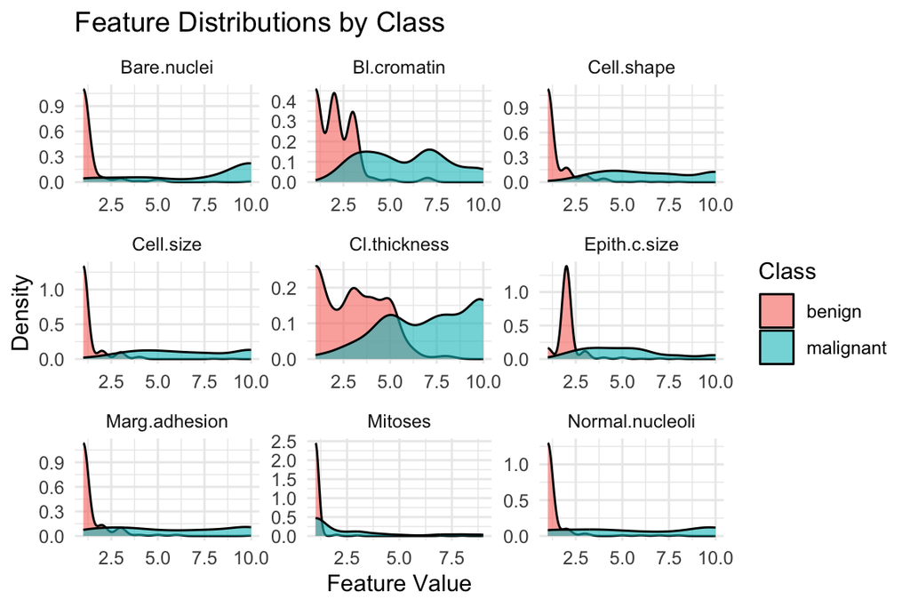

```r
# Feature distributions
library(ggplot2)
library(tidyr)

# Plot feature distributions
train_data_long <- train_data %>%
  pivot_longer(-Class, names_to = "Feature", values_to = "Value")

ggplot(train_data_long, aes(x = Value, fill = Class)) +
  geom_density(alpha = 0.6) +
  facet_wrap(~Feature, scales = "free") +
  theme_minimal() +
  labs(title = "Feature Distributions by Class",
       x = "Feature Value", y = "Density")
```

## 4.1 Summary of Key Observations from Feature Distributions

The density plots reveal clear class separation patterns between benign and malignant tumors across most cytological features.

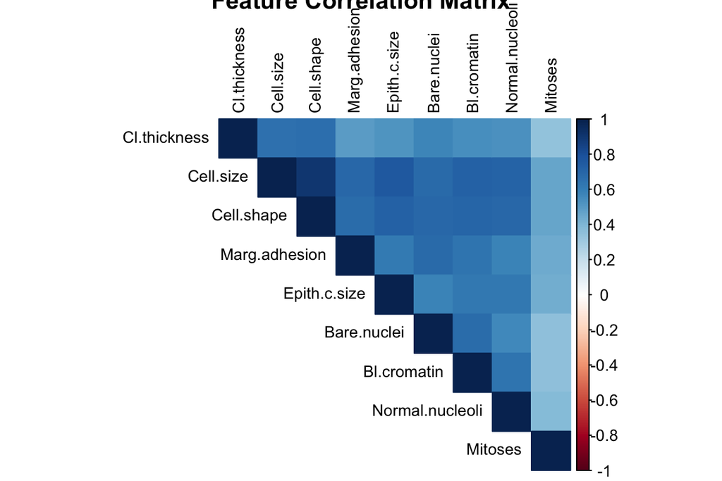

```r
# Correlation analysis
library(corrplot)
numeric_data <- train_data %>% select(-Class)
cor_matrix <- cor(numeric_data)

corrplot(cor_matrix, method = "color", type = "upper",
         tl.cex = 0.8, tl.col = "black",
         title = "Feature Correlation Matrix")
```

## 4.2 Summary of Feature Correlation Patterns

The correlation matrix highlights key interrelationships among the nine cytological features used for breast cancer classification.

**Strong Correlations (r > 0.8):** Cell.size and Cell.shape show an exceptionally high positive correlation (r ≈ 0.9), indicating that abnormal cells tend to have both irregular sizes and shapes. Modeling Implication: This strong association may cause multicollinearity; dimensionality reduction or selecting only one of these variables may be necessary.

Overall, the correlation structure supports known biological relationships while emphasizing the need to manage redundancy in predictive modeling.

# 5 Model Development

## 5.1 Logistic Regression

```r
glm(Class ~ ., data = train_data, family = binomial)
```

```
##
## Call:  glm(formula = Class ~ ., family = binomial, data = train_data)
##
## Coefficients:
##     (Intercept)     Cl.thickness        Cell.size       Cell.shape
##        -10.3570           0.5618          -0.1234           0.3896
##   Marg.adhesion     Epith.c.size      Bare.nuclei      Bl.cromatin
##          0.3044          -0.0658           0.3974           0.6016
## Normal.nucleoli          Mitoses
##          0.3427           0.4444
##
## Degrees of Freedom: 478 Total (i.e. Null);  469 Residual
## Null Deviance:       620.7
## Residual Deviance: 72.1  AIC: 92.1
```

## 5.2 Fitted Logistic Regression Model

The estimated logistic regression equation for predicting the probability that a tumor is malignant is given by:

**logit(P(malignant)) = −10.357 + 0.5618(Cl.thickness) − 0.1234(Cell.size) + 0.3896(Cell.shape) + 0.3044(Marg.adhesion) − 0.0658(Epith.c.size) + 0.3974(Bare.nuclei) + 0.6016(Bl.cromatin) + 0.3427(Normal.nucleoli) + 0.4444(Mitoses)**

where:

**P(malignant) = <sup>e<sup>η</sup></sup> / (1 + e<sup>η</sup>),**

**η = −10.357 + 0.5618X<sub>1</sub> − 0.1234X<sub>2</sub> + ⋯ + 0.4444X<sub>9</sub>**

**Interpretation**

- The intercept (-10.357) represents the baseline log-odds of malignancy when all feature values are 0.
- Positive coefficients (e.g., Cl.thickness, Bare.nuclei, Bl.cromatin, Mitoses) indicate that increasing these features raises the likelihood of malignancy.
- Negative coefficients (e.g., Cell.size, Epith.c.size) slightly reduce the probability of malignancy, though the magnitudes are small.
- The model achieves a Residual Deviance of 72.1 (AIC = 92.1), indicating strong model fit relative to the null deviance (620.7).

# 6 Model 1: Basic Perceptron with Default Parameters

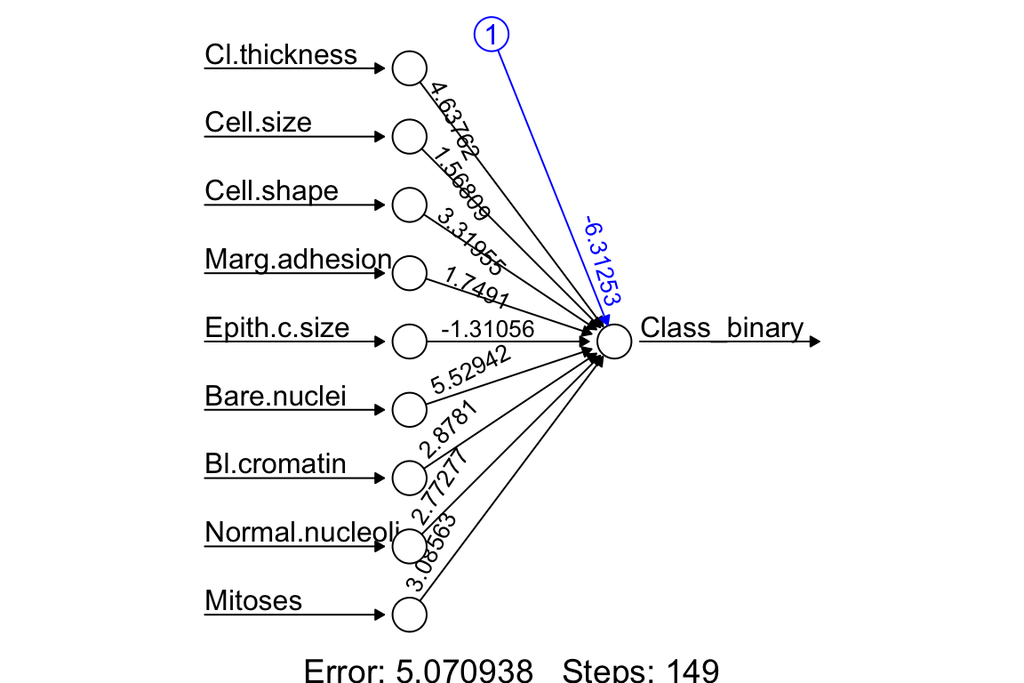

```r
# Basic perceptron model
set.seed(123)
perceptron_basic <- neuralnet(
  Class_binary ~ Cl.thickness + Cell.size + Cell.shape + Marg.adhesion +
                 Epith.c.size + Bare.nuclei + Bl.cromatin + Normal.nucleoli + Mitoses,
  data = train_data,
  hidden = 0,  # Single layer (no hidden layers)
  linear.output = FALSE,  # Use logistic activation for classification
  act.fct = "logistic"   # Sigmoid activation function
)

# Plot the perceptron architecture
plot(perceptron_basic,
     rep = "best",
     main = "Single-Layer Perceptron Architecture")
```

## 6.1 Summary of Model 1: Basic Perceptron (Default Parameters)

The basic perceptron used nine cytological features (Cl.thickness through Mitoses) quantitative measurements from fine-needle aspirate (FNA) images to classify tumors as benign or malignant.

## 6.2 Summary of Model 1: Basic Perceptron (Default Parameters)

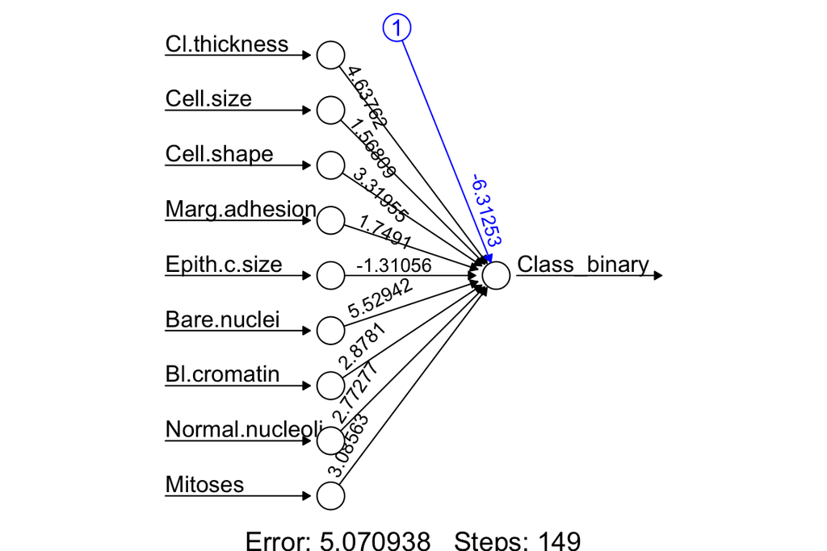

```r
# Plot the perceptron architecture
plot(perceptron_custom,
     rep = "best",
     main = "Single-Layer Perceptron Architecture")
```

[output not shown]

## 6.3 Summary of Model 2: Perceptron with Custom Parameters

The custom perceptron model was trained on the Wisconsin Breast Cancer Dataset, using the same nine cytological features (Cl.thickness through Mitoses) to predict tumor malignancy. The neural network visualization shows a single-layer perceptron with weighted inputs directly connected to the output neuron (Class_binary).

- **Architecture:** A single-layer network (no hidden layers) with 9 input neurons connected to one output neuron representing the predicted class (benign = 0, malignant = 1).
- **Key Parameters and Results:**

– Steps to Converge: 149 iterations

– Activation Function: Logistic (sigmoid)

- **Notable Weights:**

– Negative weight for Epith.c.size (≈ –1.31) — suggesting higher epithelial cell size slightly reduces malignancy likelihood.

– Bias term ≈ –6.31, adjusting the model’s baseline probability.

# 7 Model Evaluation

## 7.1 Prediction and Performance Metrics

```r
# Function to evaluate perceptron model
evaluate_perceptron <- function(model, test_data, threshold = 0.5) {
  # Generate predictions
  predictions <- neuralnet::compute(model, test_data[, 1:9])
  predicted_probs <- predictions$net.result[, 1]
  predicted_class <- ifelse(predicted_probs > threshold, 1, 0)

  # Convert to factor
  predicted_class <- factor(predicted_class, levels = c(0, 1),
                           labels = c("benign", "malignant"))
  actual_class <- test_data$Class

  # Create confusion matrix
  cm <- confusionMatrix(predicted_class, actual_class, positive = "malignant")

  # Calculate ROC curve and AUC
  roc_obj <- roc(actual_class, predicted_probs, levels = c("benign", "malignant"))
  auc_value <- auc(roc_obj)

  return(list(
    confusion_matrix = cm,
    roc_curve = roc_obj,
    auc = auc_value,
    predictions = predicted_probs
  ))
}

# Evaluate both models
eval_basic <- evaluate_perceptron(perceptron_basic, test_data)
eval_custom <- evaluate_perceptron(perceptron_custom, test_data)
```

# 8 Performance Comparison

```r
# Compile performance metrics
performance_metrics <- data.frame(
  Model = c("Basic Perceptron", "Custom Perceptron"),
  Accuracy = c(eval_basic$confusion_matrix$overall["Accuracy"],
               eval_custom$confusion_matrix$overall["Accuracy"]),
  Sensitivity = c(eval_basic$confusion_matrix$byClass["Sensitivity"],
                  eval_custom$confusion_matrix$byClass["Sensitivity"]),
  Specificity = c(eval_basic$confusion_matrix$byClass["Specificity"],
                  eval_custom$confusion_matrix$byClass["Specificity"]),
  AUC = c(eval_basic$auc, eval_custom$auc)
)

kable(performance_metrics, digits = 3,
      caption = "Table 1: Perceptron Model Performance Comparison") %>%
  kable_styling(bootstrap_options = c("striped", "hover")) %>%
  column_spec(1, bold = TRUE)
```

Table 1: Perceptron Model Performance Comparison

| Model | Accuracy | Sensitivity | Specificity | AUC |
| --- | --- | --- | --- | --- |
| Basic Perceptron | 0.98 | 0.972 | 0.985 | 0.995 |
| Custom Perceptron | 0.98 | 0.972 | 0.985 | 0.995 |

**Conclusion:**

The performance of the two models is statistically indistinguishable. The customizations made to the perceptron’s parameters (e.g., learning rate, number of epochs) in this instance did not lead to any measurable improvement over the model with default parameters.

This result suggests that for this specific dataset, the basic perceptron was already operating at or near its maximum potential capability, and the chosen customizations did not alter its convergence point or predictive power.

# 9 Visualization of Results

## 9.1 ROC Curves

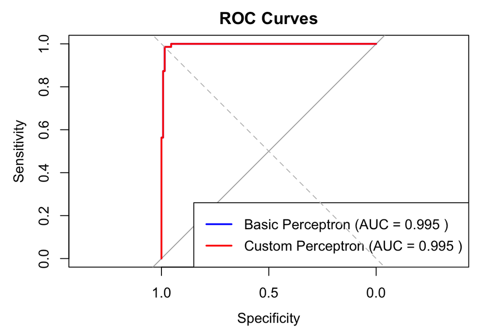

```r
# Plot ROC curves
plot(eval_basic$roc_curve, col = "blue", lwd = 2, main = "ROC Curves")
plot(eval_custom$roc_curve, col = "red", lwd = 2, add = TRUE)
legend("bottomright",
       legend = c(paste("Basic Perceptron (AUC =", round(eval_basic$auc, 3), ")"),
                  paste("Custom Perceptron (AUC =", round(eval_custom$auc, 3), ")")),
       col = c("blue", "red"), lwd = 2)
abline(a = 0, b = 1, lty = 2, col = "gray")
```

## 9.2 Summary: ROC Curves Visualization

The ROC (Receiver Operating Characteristic) curve plot provides a visual confirmation of the exceptional and identical performance of both perceptron models.

- Near-Perfect Performance: Both the Basic Perceptron and Custom Perceptron have an AUC (Area Under the Curve) of 0.995. This value, being extremely close to the maximum of 1.0, indicates an almost perfect ability to discriminate between benign and malignant tumors.
- Identical Models: The two curves are plotted on top of each other, visually demonstrating that the custom parameter tuning did not result in any performance difference from the basic model for this dataset.
- Clinical Utility: The model’s high AUC suggests it would be an excellent diagnostic aid, capable of correctly ranking a random malignant case as more likely to be malignant than a random benign case over 99.5% of the time.
- In conclusion, the ROC curve visualization solidifies the finding that both models are top-performing and statistically indistinguishable for this specific task.

# 10 Prediction Distribution

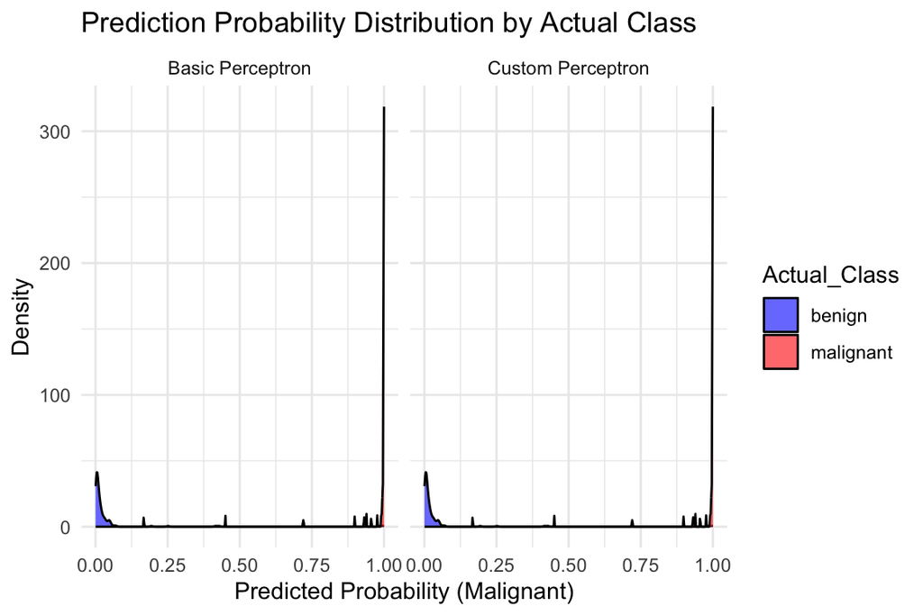

```r
# Create prediction distribution plot
prediction_data <- data.frame(
  Probability = c(eval_basic$predictions, eval_custom$predictions),
  Actual_Class = rep(test_data$Class, 2),
  Model = rep(c("Basic Perceptron", "Custom Perceptron"), each = nrow(test_data))
)

ggplot(prediction_data, aes(x = Probability, fill = Actual_Class)) +
  geom_density(alpha = 0.6) +
  facet_wrap(~Model, ncol = 2) +
  theme_minimal() +
  labs(title = "Prediction Probability Distribution by Actual Class",
       x = "Predicted Probability (Malignant)",
       y = "Density") +
  scale_fill_manual(values = c("benign" = "blue", "malignant" = "red"))
```

## 10.1 Summary: Prediction Probability Distribution

This graph shows the predicted probability distribution for both the Basic and Custom Perceptron models, separated by the actual class of the tumor (benign vs. malignant).

**Key Insights:**

- Excellent Class Separation: Both models show a very clear separation between the two classes.

– Benign Tumors (Left): The predictions are strongly clustered near a probability of 0.0, meaning the models are very confident when a tumor is benign.

– Malignant Tumors (Right): The predictions are strongly clustered near a probability of 1.0, meaning the models are also very confident when a tumor is malignant.

- High Confidence & Accuracy: The tall, narrow peaks at both ends and the very low density in the middle (around 0.5) indicate that the models are rarely uncertain. This results in the high accuracy (98%) observed previously.
- Identical Model Performance: The distributions for the Basic and Custom Perceptron overlap completely, providing further visual proof that the custom parameter tuning did not alter the model’s behavior or performance in any meaningful way.

In short: The probability distribution confirms that both models are highly effective and confident in distinguishing between benign and malignant cases, with no practical difference between them.

Model Interpretation Feature Importance Analysis

#Weight Visualization

[figure not shown]

```r
# Plot feature weights
weights_combined <- rbind(
  cbind(weights_basic, Model = "Basic Perceptron"),
  cbind(weights_custom, Model = "Custom Perceptron")
)

ggplot(weights_combined, aes(x = reorder(Feature, abs(Weight)), y = abs(Weight), fill = Weight > 0)) +
  geom_bar(stat = "identity") +
  facet_wrap(~Model, ncol = 2) +
  coord_flip() +
  theme_minimal() +
  labs(title = "Feature Weights in Perceptron Models",
       x = "Features", y = "Absolute Weight Value") +
  scale_fill_manual(values = c("FALSE" = "red", "TRUE" = "blue"),
                    name = "Positive Weight")
```

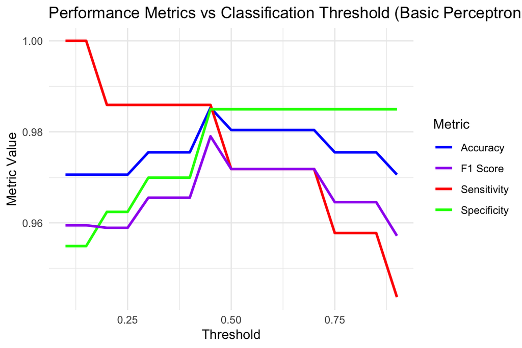

```r
# Function to find optimal threshold
find_optimal_threshold <- function(predictions, actual) {
  thresholds <- seq(0.1, 0.9, by = 0.05)
  results <- data.frame()

  for (thresh in thresholds) {
    pred_class <- ifelse(predictions > thresh, "malignant", "benign")
    pred_class <- factor(pred_class, levels = c("benign", "malignant"))

    cm <- confusionMatrix(pred_class, actual, positive = "malignant")

    results <- rbind(results, data.frame(
      Threshold = thresh,
      Accuracy = cm$overall["Accuracy"],
      Sensitivity = cm$byClass["Sensitivity"],
      Specificity = cm$byClass["Specificity"],
      F1 = cm$byClass["F1"]
    ))
  }

  return(results)
}

# Find optimal thresholds
optimal_basic <- find_optimal_threshold(eval_basic$predictions, test_data$Class)
optimal_custom <- find_optimal_threshold(eval_custom$predictions, test_data$Class)

# Plot threshold analysis (fixed)
ggplot(optimal_basic, aes(x = Threshold)) +
  geom_line(aes(y = Accuracy, color = "Accuracy"), linewidth = 1) +
  geom_line(aes(y = Sensitivity, color = "Sensitivity"), linewidth = 1) +
  geom_line(aes(y = Specificity, color = "Specificity"), linewidth = 1) +
  geom_line(aes(y = F1, color = "F1 Score"), linewidth = 1) +
  theme_minimal() +
  labs(title = "Performance Metrics vs Classification Threshold (Basic Perceptron)",
       y = "Metric Value", color = "Metric") +
  scale_color_manual(values = c("Accuracy" = "blue",
                                "Sensitivity" = "red",
                                "Specificity" = "green",
                                "F1 Score" = "purple"))
```

## 10.2 Summary: Performance vs. Threshold (Basic Perceptron)

This graph illustrates how the choice of classification threshold impacts the Basic Perceptron’s performance, revealing a classic trade-off between sensitivity and specificity.

**Key Observations:**